# Panicum virgatum DNA Extraction Test

```r
library(tidyverse)
library(tidyMB)
library(broom)
library(biobroom)
library(DESeq2)
```

## Run on home computer

```r
counts <- read_tsv("~/SGMB/PVTEST/dna_test_16s_counts.tsv")
meta <- read_tsv("~/SGMB/PVTEST/pv_test.map")
tax <- read_rds("~/RMB/Reference/gg_otus_tax.rds")
```

## Run on work computer

```r
counts <- read_tsv("~/SMB/dna_test/ninja_align/dna_test_16s_counts.tsv")
meta <- read_tsv("~/SMB/dna_test/PV_Test/pv_test.map")
tax <- read_rds("~/Reference/gg_otus_tax.rds")
```

## Gather data into a tidy object

```r
p_data <- counts %>%
  gather(PrimerCombo, value, -OTUID) %>%
  dplyr::rename(variable = "OTUID") %>%
  mutate(variable = as.character(variable)) %>%
  inner_join(meta, by = "PrimerCombo") %>%
  inner_join(tax, by = "variable") %>%
  filter(Family != "Mitochondria" & Class != "Chloroplast") %>%
  group_by(SampleID) %>%
  mutate(Depth = sum(value)) %>%
  group_by(variable) %>%
  mutate(RA = value / Depth, prevalence = sum(value > 0) / n())
```

## Do an initial PCoA on all of the data together

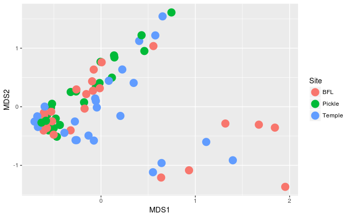

There is an ugly group of samples in the lower right hand corner. What are those and why are they so distinct?

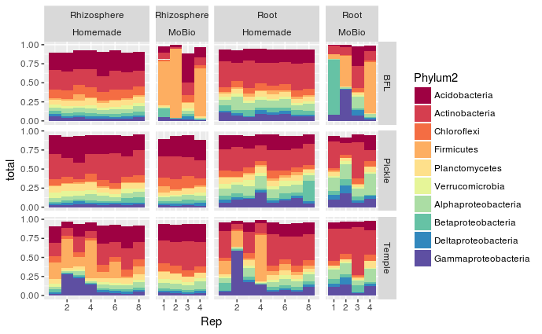

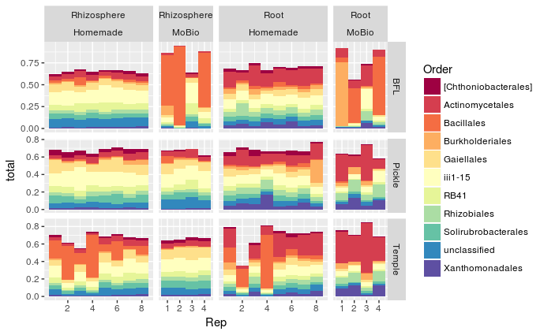

Four of the off-looking samples are in the Temple Homemade Extractions and also in the BFL MoBio samples. The off samples in the Temple rhizosphere and root are paired (i.e. the rhizosphere and endosphere orignated from the same sample). The same goes for the BFL Mobio off-samples. This leads me to believe that these roots were probably dead when I collected them. I had a particularly difficult time to finding live roots at Temple and BFL.

With this in mind, I’m going to go ahead and remove these samples from the analysis.

```r
deadSamples <- PVpc$axes %>%
  mutate(type = ifelse(MDS1 > 0.5 & MDS2 < 0, "Bad", "Good")) %>%
  filter(type == "Bad")
PVpc_good <- tidy_pcoa(p_data %>% mutate(logRA = log2(RA * 1000 + 1)) %>%
                    filter(Compartment != "Iso" & Compartment != "Zymo") %>%
                    mutate(Depth = as.character(Depth)) %>%
                    anti_join(deadSamples, by = "SampleID") %>%
                    mutate(Rep = as.character(Rep)) %>%
                    select(-Kingdom, -Class, -Order, -Phylum, -Family, -Genus, -Species, -Phylum2), value = "logRA")
```

```
Gathering metadata
Removing the column variable from the metadata.
Converting to wide table.
```

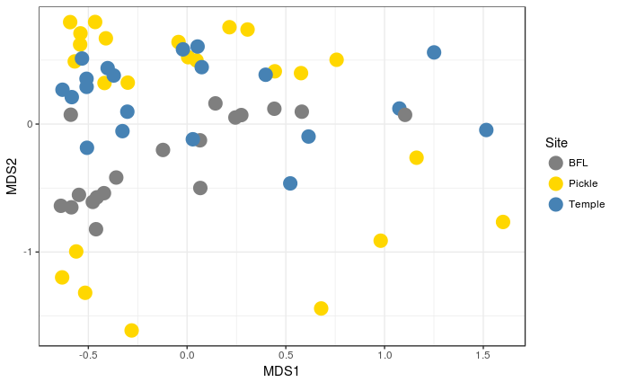

```r
PVpc_good$axes %>%
  ggplot(aes(MDS1, MDS2, color = Site, label = Rep)) +
  geom_point(size = 5) +
  scale_color_manual(values = c("grey50", "gold", "steelblue")) +
  theme_bw()
```

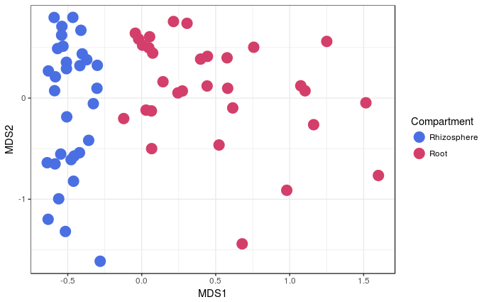

```r
PVpc_good$axes %>%
  ggplot(aes(MDS1, MDS2, color = Compartment)) +
  geom_point(size = 5) +
  scale_color_manual(values = c("#4A6FE3", "#D33F6A")) +
  theme_bw()
```

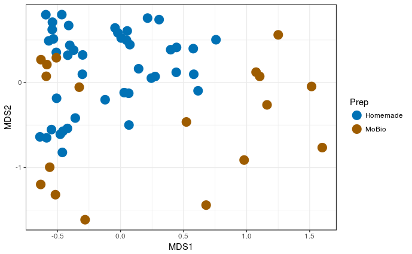

```r
PVpc_good$axes %>%
  ggplot(aes(MDS1, MDS2, color = Prep)) +
  geom_point(size = 5) +
  scale_color_manual(values = c("#0071B5", "#9E5C00")) +
  theme_bw()
```

There are a few things to mention from the above PCoAs. The one that stands out the most to me is the Pickle MoBio samples are substantially different than the Pickle Homemade DNA extraction samples. This goes for both the rhizosphere and root. I really do not have any idea what this is about. It doesn’t make that much biological sense. The other thing to note is that the the differences between the rhizosphere and root samples appear to be larger for the MoBio samples than the Homemade DNA extraction samples. I think this goes back to the lysis procedure. The way I interpret this is we are getting similar microbes in the compartment types between the extraction methods, but perhaps because we aren’t fully lysing the microbes, we are losing some of the sensitivity to the differences. This is just my gut feeling.

## Homemade sample

```r
PVpc_HM <- tidy_pcoa(p_data %>% mutate(logRA = log2(RA * 1000 + 1)) %>%
                    filter(Compartment != "Iso" & Compartment != "Zymo") %>%
                      filter(Prep == "Homemade") %>%
                      group_by(variable) %>%
                      filter(sum(value > 0) / n() > 0.1) %>%
                    mutate(Depth = as.character(Depth)) %>%
                    anti_join(deadSamples, by = "SampleID") %>%
                    mutate(Rep = as.character(Rep)) %>%
                    select(-Kingdom, -Class, -Order, -Phylum, -Family, -Genus, -Species, -Phylum2), value = "logRA")
```

```
Gathering metadata
Removing the column variable from the metadata.
Converting to wide table.
```

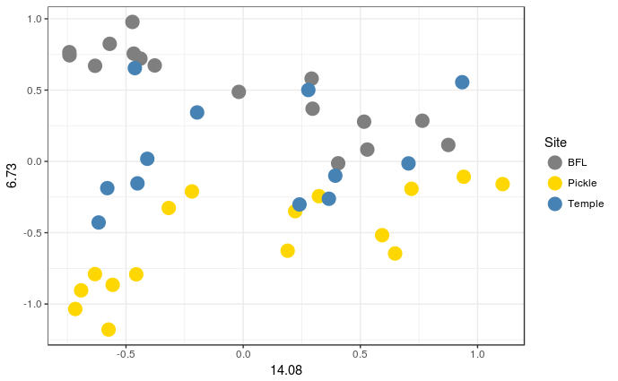

```r
PVpc_HM$axes %>%
  ggplot(aes(MDS1, MDS2, color = Site, label = Rep)) +
  geom_point(size = 5) +
  scale_color_manual(values = c("grey50", "gold", "steelblue")) +
  theme_bw() +
  labs(x = round(PVpc_HM$eigen_vals[1], 4) * 100, y = round(PVpc_HM$eigen_vals[2], 4) * 100)
```

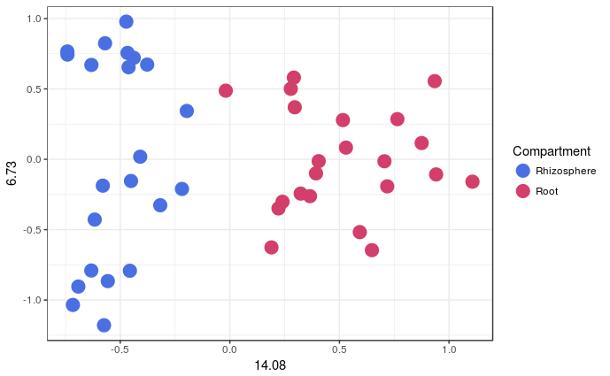

```r
PVpc_HM$axes %>%
  ggplot(aes(MDS1, MDS2, color = Compartment)) +
  geom_point(size = 5) +
  scale_color_manual(values = c("#4A6FE3", "#D33F6A")) +
  theme_bw() +
  labs(x = round(PVpc_HM$eigen_vals[1], 4) * 100, y = round(PVpc_HM$eigen_vals[2], 4) * 100)
```

Here we can see that the soil types and compartments are separating nicely with just the homemade extraction samples. Separation is better in the rhizosphere samples than the roots, but this is fairly typical.

## Permanova stats for MoBio

```r
long_adonis(p_data %>% mutate(logRA = log2(RA * 1000 + 1)) %>%
                    filter(Compartment != "Iso" & Compartment != "Zymo") %>%
                    filter(Prep == "MoBio") %>%
                    mutate(Depth = as.character(Depth)) %>%
                    anti_join(deadSamples, by = "SampleID") %>%
                    select(-Kingdom, -Class, -Order, -Phylum, -Family, -Genus, -Species, -Phylum2), value = "logRA", formula = "Site * Compartment")
```

```
Gathering metadata
Removing the column variable from the metadata.
Converting to wide table.
```

```
Permutation: free
Number of permutations: 999

Terms added sequentially (first to last)

                 Df SumsOfSqs MeanSqs F.Model      R2 Pr(>F)
Site              2   0.41523 0.20762  2.0802 0.14855  0.018 *
Compartment       1   0.94393 0.94393  9.4576 0.33768  0.001 ***
Site:Compartment  2   0.23846 0.11923  1.1946 0.08531  0.231
Residuals        12   1.19769 0.09981         0.42846
Total            17   2.79532                 1.00000
---
Signif. codes:  0 ‘***’ 0.001 ‘**’ 0.01 ‘*’ 0.05 ‘.’ 0.1 ‘ ’ 1
```

## Permanova stats for Homemade

```r
long_adonis(p_data %>% mutate(logRA = log2(RA * 1000 + 1)) %>%
                    filter(Compartment != "Iso" & Compartment != "Zymo") %>%
                    filter(Prep == "Homemade") %>%
                    mutate(Depth = as.character(Depth)) %>%
                    anti_join(deadSamples, by = "SampleID") %>%
                    select(-Kingdom, -Class, -Order, -Phylum, -Family, -Genus, -Species, -Phylum2), value = "logRA", formula = "Site * Compartment")
```

```
Gathering metadata
Removing the column variable from the metadata.
Converting to wide table.
```

```
Permutation: free
Number of permutations: 999

Terms added sequentially (first to last)

                 Df SumsOfSqs MeanSqs F.Model      R2 Pr(>F)
Site              2    0.4780 0.23900  2.6652 0.10146  0.001 ***
Compartment       1    0.5653 0.56525  6.3035 0.11999  0.001 ***
Site:Compartment  2    0.2602 0.13009  1.4507 0.05523  0.012 *
Residuals        38    3.4076 0.08967         0.72332
Total            43    4.7110                 1.00000
---
Signif. codes:  0 ‘***’ 0.001 ‘**’ 0.01 ‘*’ 0.05 ‘.’ 0.1 ‘ ’ 1
```

## Differentially Abundant Phyla and Families between compartments.

The next I did was to run a linear model to find phyla and families that are differentially abundant between the root and rhizosphere compartments in the Homemade and MoBio extractions. I reasoned that if the extraction methods are working similarly, then we should see similar taxa being enriched in each compartment for each treatment and site.

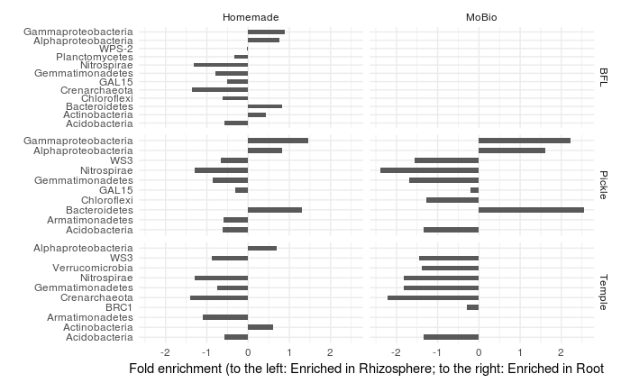

```r
DA_phy_comp <- p_data %>%
  anti_join(deadSamples, by = "SampleID") %>%
  group_by(Phylum2) %>%
  filter(Site != "x") %>%
  group_by(SampleID, Phylum2, Compartment, Prep, Site) %>%
  summarise(total = sum(RA * 1000)) %>%
  group_by(Prep, Site, Phylum2) %>%
  nest() %>%
  mutate(models = map(data, ~lm(log2(total + 1) ~ Compartment, .))) %>%
  unnest(map(models, ~tidy(.))) %>%
  filter(term != "(Intercept)") %>%
  mutate(p.adj = p.adjust(p.value, "BH")) %>%
  filter(p.adj <= 0.05)
DA_phy_comp %>%
  ggplot(aes(Phylum2, estimate)) +
  geom_bar(stat = "identity", width = 0.5) +
  facet_grid(Site ~ Prep, scales = "free_y") +
  coord_flip() +
  theme_minimal() +
  labs(x = "", y = "Fold enrichment (to the left: Enriched in Rhizosphere; to the right: Enriched in Root")
```

This graph shows that similar phyla are enriched in the compartments between the extraction methods. A few things to note: 1) There are no differentially abundant phyla in the BFL MoBio section because there was only one good sample that came from BFL for the MoBio extractions. Also, you can see that the effect sizes are larger in MoBio compared to the Homemade extractions. This is again indicative that one can detect larger differences between compartments using the MoBio extraction. Nonetheless, I think this is promising. There are no phyla that show enrichment in opposite directions between extraction techniques.

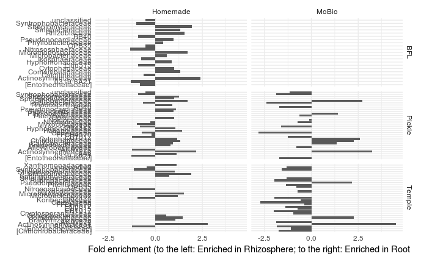

```r
DA_fam_comp <- p_data %>%
  anti_join(deadSamples, by = "SampleID") %>%
  group_by(Family) %>%
  filter(Site != "x") %>%
  group_by(SampleID, Family, Compartment, Prep, Site) %>%
  summarise(total = sum(RA * 1000)) %>%
  group_by(Prep, Site, Family) %>%
  nest() %>%
  mutate(models = map(data, ~lm(log2(total + 1) ~ Compartment, .))) %>%
  unnest(map(models, ~tidy(.))) %>%
  filter(term != "(Intercept)") %>%
  mutate(p.adj = p.adjust(p.value, "BH")) %>%
  filter(p.adj <= 0.05)
DA_fam_comp %>%
  ggplot(aes(Family, estimate)) +
  geom_bar(stat = "identity", size = 0.5) +
  facet_grid(Site ~ Prep, scales = "free_y") +
  coord_flip() +
  theme_minimal() +
  labs(x = "", y = "Fold enrichment (to the left: Enriched in Rhizosphere; to the right: Enriched in Root")
```

There is a similar story for bacterial families.

## Differentially abundant OTUs

```r
DEseq_pv <- p_data %>%
  filter(Site != "BFL") %>%
  anti_join(deadSamples, by = "SampleID") %>%
  filter(Compartment == "Root" | Compartment == "Rhizosphere") %>%
  dplyr::select(Compartment, Site, value, variable, Prep, SampleID) %>%
  group_by(variable) %>%
  filter(sum(value > 0) / n() > 0.1) %>%
  mutate(group = paste(Prep, Compartment, Site, sep= ".")) %>%
  group_by(group_var = "DESeq2") %>%
  nest() %>%
  mutate(DGEL = map(data, ~tidyDGEL(., value = "value", group_column = "group", method = "DESeq2", formula = "~ group"))) %>%
  mutate(dds = map(DGEL, ~DESeq(.))) %>%
  mutate(mb_pick = map(dds, ~lfcShrink(., contrast = c("group", "MoBio.Rhizosphere.Pickle", "MoBio.Root.Pickle"))),
         hm_pick = map(dds, ~lfcShrink(., contrast = c("group", "Homemade.Rhizosphere.Pickle", "Homemade.Root.Pickle"))),
         mb_temp = map(dds, ~lfcShrink(., contrast = c("group", "MoBio.Rhizosphere.Temple", "MoBio.Root.Temple"))),
         hm_temp= map(dds, ~lfcShrink(., contrast = c("group", "Homemade.Rhizosphere.Temple", "Homemade.Root.Temple")))) %>%
  dplyr::select(mb_pick, hm_pick, mb_temp, hm_temp, group_var) %>%
  gather(key = comparison, value = results, -group_var)
```

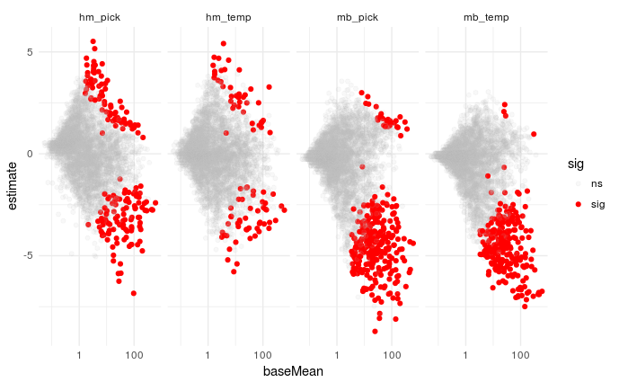

| direction | Site | n | nn |
| --- | --- | --- | --- |
| Rhizosphere | pick | 2 | 2 |
| Root | pick | 2 | 81 |
| Root | temp | 2 | 36 |

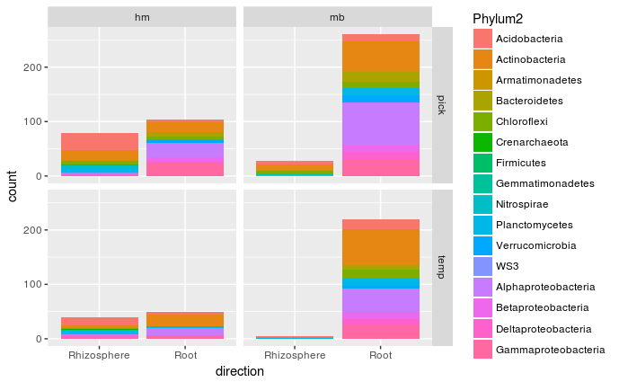